# Desafio II

Estatística Espacial I

[figure not shown]

# 1 Objetivo

O estudo se baseia no conjunto de dados referentes a segurados de uma empresa e residentes no município do Rio de Janeiro.

As informações contêm a localização geográfica das residências dos segurados e seus devidos prêmios do seguro.

Os pesquisadores Igor Freitas e João Pedro Fernandes, recém-contratados por uma empresa de seguro de automóveis, estão encarregados de precificar o valor pago pelos segurados, analisando a dependência espacial na região estudada.

# 2 Análises exploratórias

## 2.1 Parte I

Os dados totalizam 211 observações de 3 variáveis, referentes à latitude e à longitude das residências dos segurados e ao prêmio do seguro para pessoas que residem no município do Rio de Janeiro.

Como é possível observar no mapa abaixo, grande parte dos pontos se localizam à direita do mapa, o que ocasiona vazios em relação às observações principalmente na Zona Oeste da cidade.

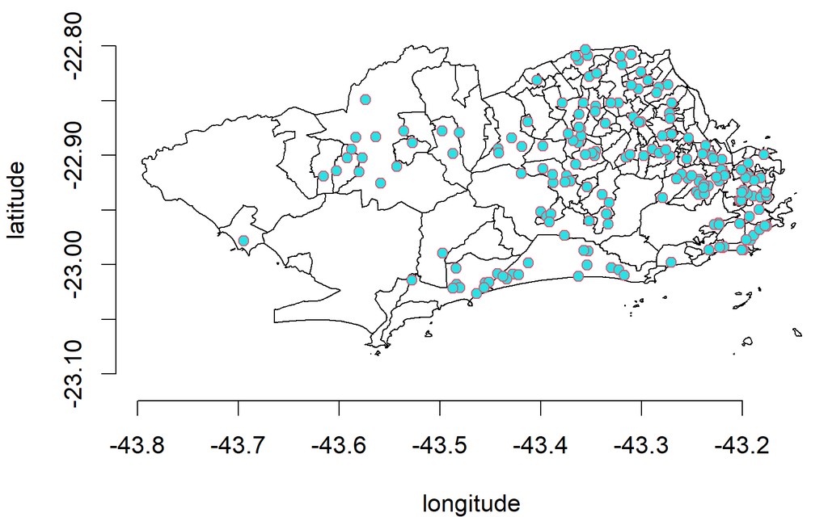

**Figura 1 - Mapa do município do Rio de Janeiro com as observações referentes às residências dos segurados**

## 2.2 Parte II

Analisando histogramas, chega-se à conclusão que os valores do prêmio têm comportamento assimétrico, com maior variabilidade, já que há pontos cujos valores de seguro são muito altos (outliers). Já o log do prêmio apresenta comportamento se assemelhando à distribuição normal, diminuindo a variabiidade e estabilizando um pouco a incerteza. Dessa forma, escolhe-se modelar o logaritmo do prêmio.

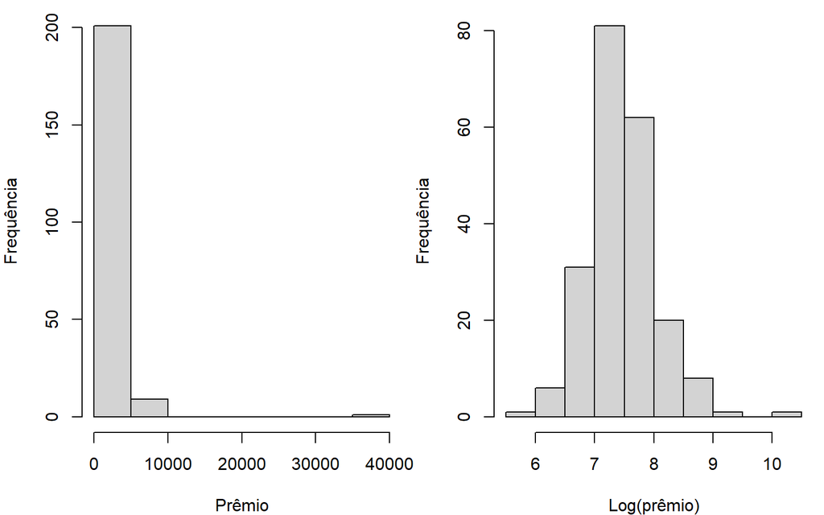

**Figura 2 - Histogramas do prêmio e do logaritmo do prêmio dos segurados**

# 3 Análise geoestatística

## 3.1 Parte I

Interpretando os gráficos gerados a seguir (Figura 3), percebe-se que a maioria das observações relativas às residências dos segurados se encontram na faixa nordeste do município (ao norte e ao leste) e que os valores do logaritmo do prêmio pago pelo segurado estão concentrados entre 7 e 8, em média, e aparentam apresentar distribuição normal.

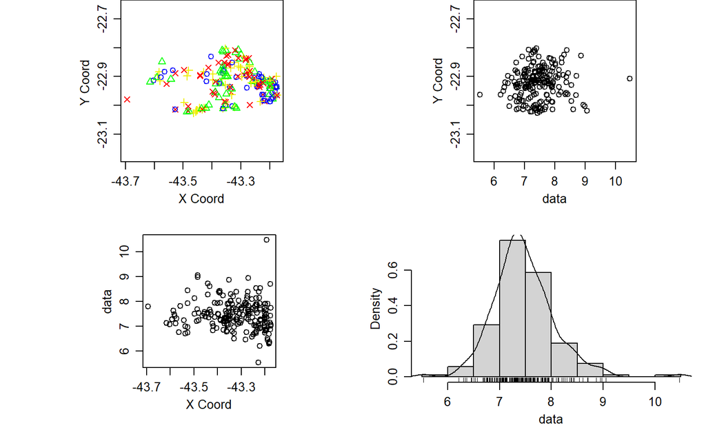

**Figura 3- Gráficos referentes às localizações geográficas das residências dos segurados e o logaritmo do prêmio**

Pela Figura 4, são tiradas algumas indicações a partir do gráfico. Os segurados na faixa à noroeste apresentam valores próximos de prêmios, assim como os residentes da Zona Sul, por exemplo.

É possível notar que os maiores valores de prêmios a serem pagos pelos segurados estão, principalmente, à direita e acima do gráfico (maior presença de bolhas brancas).

Também observa-se que praticamente todas as regiões apresentam observações com pequeno valor de prêmio (bolhas verdes ou amarelas) ao mesmo tempo que observações com valores de prêmio maiores (bolhas rosas ou brancas).

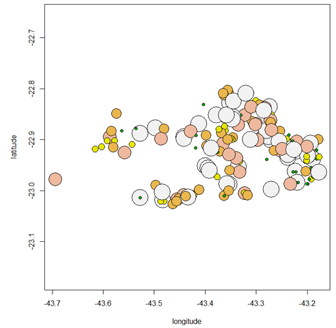

**Figura 4 - Gráfico de quantis dos valores do logaritmo do prêmio pelo segurado**

## 3.2 Parte II

Analisando o semivariograma empírico e a tendência estimada por máxima verossimilhança (Figura 5), verifica-se que, após testar os modelos da família matern, esférica, exponencial e gaussiana, optou-se pela utilização do modelo gaussiano.

O alcance (distância até se chegar no patamar) encontrado foi bem pequeno, indicando uma subida rápida nos valores do semivariograma. Assim, já para pequenas distâncias, não há tanta dependência espacial.

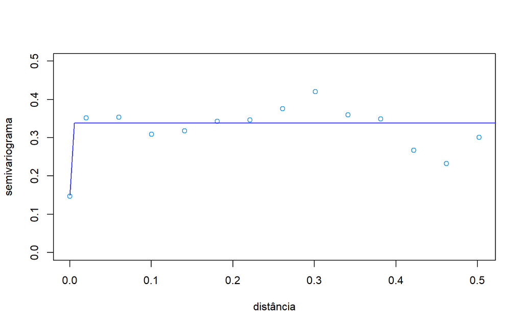

**Figura 5 - Semivariograma empírico**

## 3.3 Parte III

De acordo com a Figura 6, é possível tirar algumas conclusões:

- existem regiões com prêmios muito altos, porém com locais na mesma região com valores de prêmios baixos;
- confirmando o alcance pequeno observado anteriormente: próximo à região escura, em pequenas distâncias já não há dependências expressivas entre os dados;
- a Zona Sul e a faixa mais à oeste do mapa aparentam apresentar os valores de prêmios mais baixos e as regiões com vias expressas, próximos de locais favelizados e na divisa de municípios, por exemplo, os mais altos.

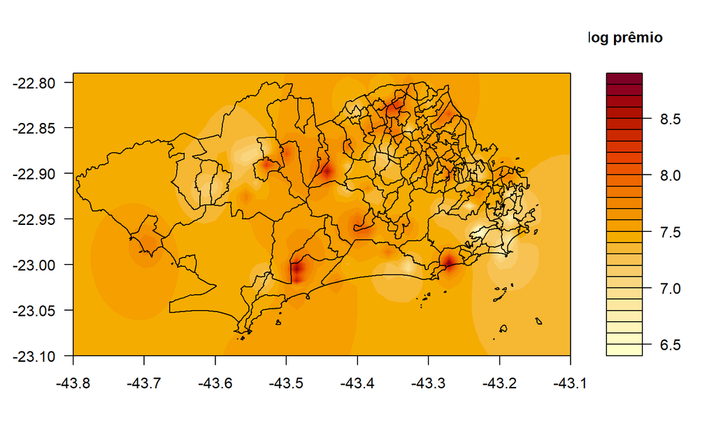

**Figura 6 - Mapa com a interpolação ponderada pelo inverso da distância**

## 3.4 Parte IV

Pelo histograma a seguir, usando uma janela de 2.500 pontos preditos, percebe-se que o y ajustado parece ter distribuição normal com valores em torno de 7 e 8 e média próxima a 7,5.

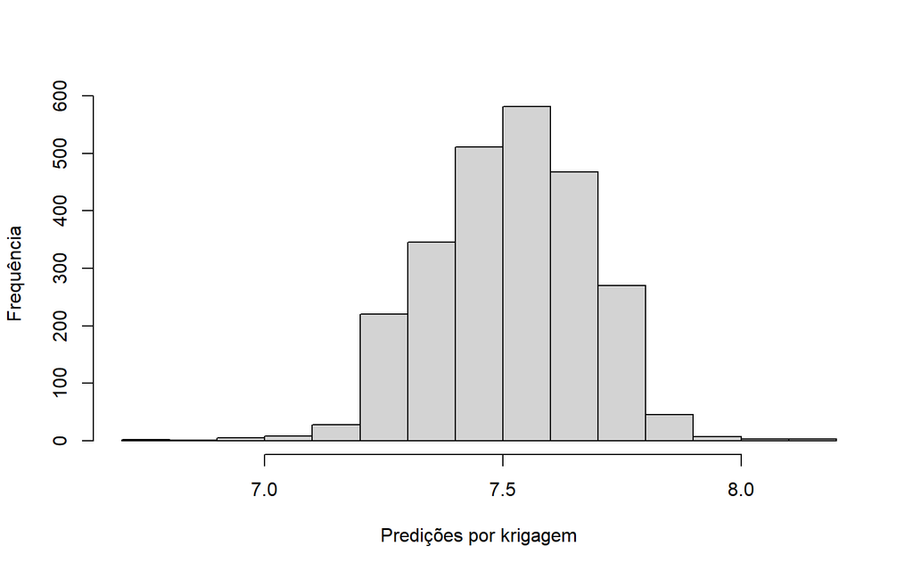

**Figura 7- Histograma dos valores do logaritmo do prêmio preditos por krigagem simples**

Pela superfície apresentada na Figura 8, os menores valores a serem pagos pelos segurados são os de residentes em zonas nobres, como a Zona Sul.

Em comparação, os maiores prêmios estão concentrados em regiões que cruzam vias expressas, divisas de municípios, dentre outras áreas espalhadas pela cidade.

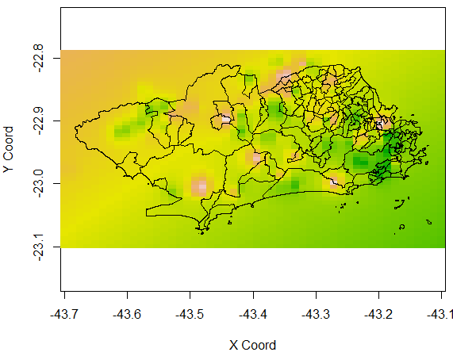

**Figura 8- Superfície de predição média dos valores do prêmio a partir de krigagem simples**

Na Figura 9, percebe-se que na Zona Oeste, principalmente, há poucas observações registradas, o que gera uma grande incerteza sobre as predições dos valores do prêmio nessa região.

O que não ocorre na parte mais ao leste e ao norte do mapa, em que existe mais certeza encontrada, ou seja, muitos pontos ao redor e menor variância de predição.

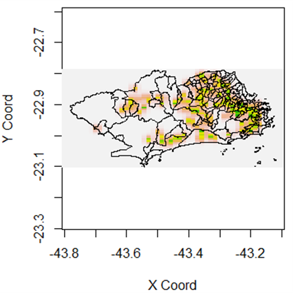

**Figura 9- Superfície de variância de predição dos valores do prêmio a partir de krigagem simples**

# 4 Conclusões

Neste trabalho, após traçar um objetivo inicial, foram feitas análises exploratórias e geoestatísticas por meio de gráficos e mapas.

Com isso, foi possibilitado plotar o semivariograma empírico e estimar a tendência por máxima verossimilhança após testar diferentes modelos. O alcance encontrado foi pequeno, o que indicou que para distâncias já não muito grandes, a dependência espacial não era expressiva.

Por fim, é possível concluir que, através dos métodos de interpolação ponderada pelo inverso da distância e krigagem simples:

- as regiões com prêmios mais altos estão localizadas em áreas como as de vias expressas, divisa de municípios, principalmente mais ao norte e à direita do mapa da cidade;
- já os menores valores a serem pagos pelos segurados são os de residentes em zonas nobres, como a Zona Sul;
- a Zona Oeste apresenta poucas observações registradas, ocasionando uma certa incerteza sobre as predições dos valores do prêmio nessa região, ao contrário das zonas mais ao leste e ao norte do mapa, que possuem menor variabilidade em relação às suas observações.